# Survey Planning and Review Using PRIMR Data: Tetlin NWR Case Study

## 2023 Survey Review

### **Expected for 2023**

**Survey Count:** 18

**Total Cost:** $404,665.00

**Non-labor Operations Cost:** $161,882.50

**FWS Staff Hours:** 5613

**Time Per Coordinator:**

*‘Time per coordinator’ includes time allocated to support staff, if applicable.*

1. Travis David - 22 hours | 3 work days | 1.195% of work year
2. Brent Jamison - 5591 hours | 699 work days | 278.486% of work year

### **Completed for 2023**

*‘Completed’ in this case refers to data acquired.*

**Survey Count:** 12

**Total Cost:** $178,258.00

**Non-labor Operations Cost:** $42,382.50

**FWS Staff Hours:** 2677

**Time Per Coordinator:**

*‘Time per coordinator’ includes time allocated to support staff, if applicable.*

1. Travis David - 22 hours | 3 work days | 1.195% of work year
2. Brent Jamison - 2655 hours | 332 work days | 132.271% of work year

### Survey Completion Level

|  | Survey Title | Acquired | Digitized | Reviewed | Evaluated | Communicated | Preserved |
| --- | --- | --- | --- | --- | --- | --- | --- |
| 1 | Christmas Bird Count | TRUE | TRUE | TRUE | FALSE | FALSE | FALSE |
| 2 | Breeding Bird Survey | TRUE | TRUE | TRUE | FALSE | FALSE | FALSE |
| 3 | Snowshoe Hare Population Monitoring | TRUE | TRUE | TRUE | TRUE | FALSE | FALSE |
| 4 | Alaska Landbird Monitoring Survey (ALMS) | TRUE | TRUE | TRUE | FALSE | FALSE | FALSE |
| 5 | Snowpack Monitoring | TRUE | TRUE | TRUE | TRUE | TRUE | TRUE |
| 6 | Invasive Plant Control at Point Sources on the Alaska Highway | TRUE | TRUE | TRUE | TRUE | TRUE | TRUE |
| 7 | Water Quantity & Quality Monitoring at Scottie Creek and Nabesna River | TRUE | TRUE | TRUE | TRUE | TRUE | FALSE |
| 8 | Invasive Plant Occurrence along the Tetlin NWR/Alaska Highway Corridor | TRUE | TRUE | TRUE | TRUE | TRUE | FALSE |
| 9 | Aquatic Invertebrate Inventory | FALSE | FALSE | FALSE | FALSE | FALSE | FALSE |
| 10 | Water Temperature Monitoring of Streams | FALSE | FALSE | FALSE | FALSE | FALSE | FALSE |
| 11 | Osprey and Bald Eagle Nest Occupancy and Productivity Surveys | FALSE | FALSE | FALSE | FALSE | FALSE | FALSE |
| 12 | Canada Lynx Dispersal, Space and Habitat Use Patterns During a Snowshoe Hare Population Cycle | TRUE | TRUE | TRUE | TRUE | TRUE | FALSE |
| 13 | Early Detection Rapid Response Monitoring for Exotic Forest Pests | FALSE | FALSE | FALSE | FALSE | FALSE | FALSE |
| 14 | Moose Twinning Survey | TRUE | TRUE | TRUE | TRUE | TRUE | FALSE |
| 15 | Waterfowl Banding - dabblers | TRUE | TRUE | TRUE | TRUE | FALSE | FALSE |
| 16 | Scaup and Scoter breeding pair survey | TRUE | TRUE | TRUE | FALSE | FALSE | FALSE |
| 17 | Scaup and Scoter Brood Survey | FALSE | FALSE | FALSE | FALSE | FALSE | FALSE |
| 18 | Waterfowl Banding - divers/sea ducks | FALSE | FALSE | FALSE | FALSE | FALSE | FALSE |

## 2024 Survey Planning

### **Expected for 2024**

**Survey Count:** 16

**Total Cost:** $354,164.00

**Non-labor Operations Cost:** $152,082.50

**FWS Staff Hours:** 4496

**Time Per Coordinator:**

*‘Time per coordinator’ includes time allocated to support staff, if applicable.*

1. Travis David - 22 hours | 3 work days | 1.195% of work year
2. Brent Jamison - 4474 hours | 560 work days | 223.108% of work year

### Expected 2024 Survey List

|  | Survey Title | Schedule | Time Required(Hrs) | Total Cost($) | Non-Labor Cost($) | Coordinator | Partner-Led? | Internal Partners? | External Partners? | Pertaining to pROCs? | IMP Table 1 Ranking | Other Refuges Monitoring Species |
| --- | --- | --- | --- | --- | --- | --- | --- | --- | --- | --- | --- | --- |
| 1 | Christmas Bird Count | DEC-JAN | 22 | 946 | 100.0 | Travis David | TRUE | FALSE | TRUE | TRUE | 20 | Kenai, Kodiak |
| 2 | Breeding Bird Survey | JUN | 24 | 3612 | 150.0 | Brent Jamison | TRUE | TRUE | TRUE | TRUE | 16 | Kanuti, Kenai, Koyukuk, Arctic, Yukon Delta, Izembek |
| 3 | Snowshoe Hare Population Monitoring | SUM | 74 | 3246 | 400.0 | Brent Jamison | TRUE | FALSE | TRUE | TRUE | 17 | Kenai, Koyukuk, Yukon Flats |
| 4 | Alaska Landbird Monitoring Survey (ALMS) | 10-30 JUN | 24 | 7615 | 2000.0 | Brent Jamison | TRUE | FALSE | TRUE | TRUE | 19 | Kenai, Koyukuk |
| 5 | Snowpack Monitoring | 5x / WIN (1Dec, 1Feb, 1Mar, 1Apr, and 1May) | 80 | 4577 | 1500.0 | Brent Jamison | TRUE | FALSE | TRUE | FALSE | 18 |  |
| 6 | Invasive Plant Control at Point Sources on the Alaska Highway | JUN-JUL | 40 | 2308 | 0.0 | Brent Jamison | TRUE | FALSE | TRUE | FALSE | 7 | Kanuti, Kenai |
| 7 | Water Quantity & Quality Monitoring at Scottie Creek and Nabesna River | 6x / yr | 222 | 9423 | 885.0 | Brent Jamison | TRUE | TRUE | TRUE | FALSE | 13 |  |
| 8 | Invasive Plant Occurrence along the Tetlin NWR/Alaska Highway Corridor | JUN-JUL | 8 | 6231 | 2000.0 | Brent Jamison | TRUE | TRUE | FALSE | FALSE | 1 | Kanuti, Kenai |
| 9 | Water Temperature Monitoring of Streams | continuously | 40 | 3846 | 0.0 | Brent Jamison | TRUE | TRUE | TRUE | FALSE | 14 |  |
| 10 | Canada Lynx Dispersal, Space and Habitat Use Patterns During a Snowshoe Hare Population Cycle | JAN-APR; not regular/opportunistic APR-OCT; OCT-DEC | 1595 | 91013 | 14330.0 | Brent Jamison | TRUE | TRUE | TRUE | TRUE | 15 | Kanuti, Kenai, Koyukuk, Yukon Flats |
| 11 | Early Detection Rapid Response Monitoring for Exotic Forest Pests | MAY-SEP | 80 | 4639 | NA | Brent Jamison | TRUE | FALSE | TRUE | FALSE | 21 |  |
| 12 | Moose Twinning Survey | Late SPR | 80 | 10556 | 9017.5 | Brent Jamison | TRUE | FALSE | TRUE | TRUE | 11 | Kanuti, Kenai, Alaska Peninsula, Selawik, Koyukuk, Arctic, Yukon Delta, Yukon Flats, Togiak |
| 13 | Waterfowl Banding - dabblers | JUL-AUG | 320 | 16846 | 3000.0 | Brent Jamison | TRUE | TRUE | FALSE | FALSE | 9 | Kanuti, Koyukuk, Yukon Delta, Izembek |
| 14 | Scaup and Scoter breeding pair survey | JUN | 188 | 21885 | 9000.0 | Brent Jamison | FALSE | TRUE | FALSE | TRUE | 3 | Kanuti, Kenai, Kodiak, Koyukuk, Yukon Delta, Izembek |
| 15 | Waterfowl Banding - divers/sea ducks | JUL-AUG | 1698 | 67229 | 9700.0 | Brent Jamison | FALSE | TRUE | FALSE | TRUE | 5 | Kanuti, Kenai, Kodiak, Koyukuk, Yukon Delta, Izembek |
| 16 | Wood Bison Conservation Research | JAN-DEC | 1 | 100192 | 100000.0 | Brent Jamison | TRUE | TRUE | TRUE | TRUE | NA | Kenai, Selawik, Yukon Flats |

### Known Priorities (nROC Names) for Comparison

| Resource Name |
| --- |
| Swans |
| Waterfowl (dabblers/divers/seaducks) |
| Ungulate |
| Humpback whitefish |
| Raptors |
| Landbirds |
| Furbearers |

## Imperfect Derivations

*Costs/Hours Used in 2023*

It was assumed that full costs and hours were used for any survey where the data acquisition step was completed, regardless of whether later steps in the survey cycle were completed.

*Expected Surveys for 2024*

The list of expected surveys for 2024 was based on predictions of the next scheduled year for each survey, derived under the assumption of no changes in survey frequency over time.

If there was at least one year of reporting where data acquisition was scheduled (defined by Acquired = TRUE or Acquired = FALSE with any reason selected other than “Not Scheduled”), the maximum among them was used as the most recent known year of the survey being scheduled, hereinafter denoted “x”. If there were no years of reported scheduled data acquisition, the survey start year was used as the value of “x”. The survey frequency was then iteratively applied to “x” until a year of 2024 or later was reached.

If the prediction for the next scheduled survey year exceeded the end year of the survey, the next scheduled year was replaced with the end year value.

*Count of Work Days and Percent of Work Year*

These values assume an 8-hour work day and a 251-day (weekdays minus federal holidays) work year (varies slightly by year).

*Non-Labor Operations Cost Total*

If this field was left blank in PRIMR, an operations cost of $0 was assumed.

*Pertaining to pROCs (Boolean)*

A species list (scientific names) for each survey was compiled starting with listed and non-listed species, if provided. If “species” provided were only one word, this was assumed to be a genus, and all species of that genus in the refuge’s NWRspecies records were added to the species list for the survey. If no species were provided, the level 2 biotic groups were instead used. The biotic group scientific name was matched to a taxanomic order in the refuge’s NWRSpecies data, and all species of that order were added to the species list for the survey. If the biotic group did not match any orders in the NWRSpecies data, it instead was matched to a family, and the same procedures were applied.

The pROC list for the refuge was compiled from nROC scientific names in our IMP dataset and was supplemented with known synonyms of taxa when applicable. If any species in a survey’s species list was found in the pROC list, this field was set to “TRUE”.

## Limitations

1. **Inability to accurately predict upcoming scheduled surveys**

There are limited frequency options: sporadic/ad hoc, once, yearly, 2 years, 3 years, 4 years, 5 years, and 10 years.

Surveys with “sporadic” or “once” frequencies are not possible to predict scheduling for.

The `frequency` and `startDate` fields fail to capture changes in frequency over time and unplanned gaps, which we know occur with many long-term surveys.

Note: not all “scheduled” surveys are expected to occur.

**Example Data #1**

Showing data on current and expected surveys only

| name | startYear | endYear | frequencyType | lastScheduled | nextScheduled | descr |
| --- | --- | --- | --- | --- | --- | --- |
| Christmas Bird Count | 1986 | Indefinite | Recurring -- every year | 2023 | 2024 | Field work coordinated by VS staff at Tetlin NWR |
| Breeding Bird Survey | 1989 | Indefinite | Recurring -- every year | 2023 | 2024 | Tetlin NWR provides coordination and logistical support for field staff |
| Snowshoe Hare Population Monitoring | 1990 | Indefinite | Recurring -- every year | 2023 | 2024 | Field data collected |
| Alaska Landbird Monitoring Survey (ALMS) | 1994 | Indefinite | Recurring -- every year | 2023 | 2024 | Tetlin NWR coordinated schedules and provided logistical support in form of lodging and transportation to field sites |
| Trumpeter Swan Survey | 1983 | Indefinite | Recurring -- every five years | 2018 | 2028 | 5-yr interval. Next survey scheduled 2027 |
| Snowpack Monitoring | 1992 | Indefinite | Recurring -- every year | 2023 | 2024 | Some field work conducted by Tetlin NWR. Data were not collected at all sites do to limited staff time. |
| Invasive Plant Control at Point Sources on the Alaska Highway | 2004 | Indefinite | Recurring -- every year | 2023 | 2024 | SCA intern conducted surveys, weed pull, and reporting was completed to invasive program |
| Moose Population Monitoring | 1990 | Indefinite | Recurring -- every three years | 2017 | 2026 | NA |
| Water Quantity & Quality Monitoring at Scottie Creek and Nabesna River | 2005 | Indefinite | Recurring -- every year | 2023 | 2024 | Field work conducted in coop with water resources and NPS. Data managed and reporting conducted by partners. |
| Invasive Plant Occurrence along the Tetlin NWR/Alaska Highway Corridor | 2021 | 2031 | Occurs one time only | 2023 | 2024 | Invasives team conducted survey |
| Aquatic Invertebrate Inventory | 2022 | 2036 | Recurring -- every five years | 2023 | 2028 | NA |
| Water Temperature Monitoring of Streams | 2010 | Indefinite | Recurring -- every year | 2023 | 2024 | data loggers deployed in 2022 and 2023 were lost due to ice and high water. |
| Humpback Whitefish Spawning Populations: Monitoring the Effects of Harvest Level by Age Structure Analysis | 2017 | Indefinite | Recurring -- every decade | NA | 2027 | 5-yr survey interval - sampling scheduled for 2026 |
| Osprey and Bald Eagle Nest Occupancy and Productivity Surveys | 1991 | Indefinite | Recurring -- every three years | 2023 | 2026 | Management determined surveys were cost-prohibitive in 2021. |
| Canada Lynx Dispersal, Space and Habitat Use Patterns During a Snowshoe Hare Population Cycle | 2014 | 2025 | Recurring -- every year | 2023 | 2024 | NA |
| Early Detection Rapid Response Monitoring for Exotic Forest Pests | 2010 | Indefinite | Recurring -- every year | 2023 | 2024 | Sampling on indefinite hold due to lack of partner resources |
| Moose Twinning Survey | 2021 | Indefinite | Recurring -- every year | 2023 | 2024 | Survey and reporting completed; document in Servcat |
| Waterfowl Banding - dabblers | 2018 | Indefinite | Recurring -- every year | 2023 | 2024 | Field work conducted by volunteers at Tetlin NWR; data management/reporting conducted by BBL |
| Scaup and Scoter breeding pair survey | 2022 | 2036 | Recurring -- every year | 2023 | 2024 | Survey flights complete |
| Scaup and Scoter Brood Survey | 2022 | 2036 | Recurring -- every three years | 2023 | 2026 | Sample sizes required to estimate production or detect trends are greater than that which can be collected with current staff/'funding. |
| Waterfowl Banding - divers/sea ducks | 2022 | 2036 | Recurring -- every year | 2023 | 2024 | NA |
| Wetland Mapping and Remote Sensing Monitoring | 2021 | Indefinite | Recurring -- every five years | 2021 | 2026 | 5-yr interval; next mapping effort scheduled for 2027 |
| Wood Bison Conservation Research | 2022 | Indefinite | Recurring -- every year | NA | 2024 | NA |

*bold* - indicates derived values (not in PRIMR)

*purple background* - indicates incorrectly predicted “next scheduled” date

*green background* - indicates current surveys that are not actually expected to occur

Note: `descr` field pulled from comments added to data acquisition question in most recent annual activity reporting

2. **Inability to use or interpret survey timing field**

The field is not standardized, and it is unclear whether it feasibly could be. This prevents PRIMR from being effective for survey scheduling.

**Example Data #2**

Showing data on all surveys

| name | surveyTiming |
| --- | --- |
| Cow Moose Distribution on Tetlin NWR | NA |
| Waterfowl Breeding Pair Survey | Between 15 May and 1 June |
| Christmas Bird Count | DEC-JAN |
| Landbird Migration Monitoring - Fall Banding Station | August and September |
| Breeding Bird Survey | JUN |
| Snowshoe Hare Population Monitoring | SUM |
| Alaska Landbird Monitoring Survey (ALMS) | 10-30 JUN |
| Trumpeter Swan Survey | AUG |
| Relationship of Wildland Fire Severity to Furbearer Distribution and Abundance on Tetlin NWR | NA |
| Peregrine Falcon Nest Occupancy and Productivity Surveys | May through August |
| North American Bird Migration Count | second Saturday in May |
| Carbon Sequestration and Ecosystem Services in the Boreal Forest | NA |
| Water Quantity & Quality Baseline Monitoring | Six times per year in May, July, September, November, January and March |
| Snowpack Monitoring | 5x / WIN (1Dec, 1Feb, 1Mar, 1Apr, and 1May) |
| Rusty Blackbird Breeding Ecology and Habitat Affinities | May through August |
| Invasive Plant Control at Point Sources on the Alaska Highway | JUN-JUL |
| Phenology Monitoring of Spring Bird Migration | 2-3 times per week late March through early June each year |
| Moose Population Monitoring | FALL |
| Waterfowl Production on Tetlin NWR | NA |
| Wetland Value for Breeding Waterbirds: an Assessment | May through August |
| Effects of Climate Change on the Distribution, Abundance, Productivity, and Survival of Boreal Wetland and Forest Birds and their Habitats | NA |
| Water Quantity & Quality Monitoring at Scottie Creek and Nabesna River | 6x / yr |
| Invasive Plant Occurrence along the Tetlin NWR/Alaska Highway Corridor | JUN-JUL |
| Humpback Whitefish Spawning Location Water Quality and Hydrology Database | NA |
| Aquatic Invertebrate Inventory | JUL |
| Landcover Change Analysis of Tetlin NWR | NA |
| Fire Effects on the Establishment and Spread of Invasive Plants Adjacent to Highway Corridors | NA |
| Vegetation Inventory | July and August |
| Fire Severity and Post-fire Seral Stage Effects on Furbearer Distribution and Abundance | NA |
| Caribou Distribution Monitoring | October through April |
| Water Temperature Monitoring of Streams | continuously |
| Moose Winter Habitat Monitoring | NA |
| Fire Severity Effects on Small Mammal Distribution and Abundance | NA |
| Effects of Fire on Water Quality and Hydrology in Boreal Forests | NA |
| Quantify the Contribution of Tetlin NWR to Large Scale Ecological Performance | NA |
| Small Mammal Inventory | May through August |
| Humpback Whitefish Spawning Populations: Monitoring the Effects of Harvest Level by Age Structure Analysis | FALL |
| Trumpeter Swan Habitat Occupancy and Productivity in a Rapidly Expanding Population | May through August |
| Sandhill Crane and Swan Migration in the Upper Tanana Valley | April and May |
| Wolf Population Monitoring | A pilot effort was conducted in 2003 but the survey has not been continued. |
| Caribou Winter Range Assessment | NA |
| Brown and Black Bear Population Monitoring | NA |
| Owl Monitoring | February/March |
| Environmental Affects on Plant Communities on Tetlin NWR | NA |
| Muskrat Population Monitoring | NA |
| Dall Sheep Population Monitoring | NA |
| Coyote Population Survey | NA |
| Waterfowl Brood Survey | July 5-15 |
| Phenology (US National Phenology Network) Plots | 2-3 times per week May through September; 2010 was a pilot year |
| Osprey and Bald Eagle Nest Occupancy and Productivity Surveys | MAY-JUN |
| Wolverine Survey | February |
| Olive-sided Flycatcher Migratory Connectivity | June |
| Lake Area Change in Alaska National Wildlife Refuges | NA |
| Canada Lynx Dispersal, Space and Habitat Use Patterns During a Snowshoe Hare Population Cycle | JAN-APR; not regular/opportunistic APR-OCT; OCT-DEC |
| Scaup/Scoter Survey: expanded to Boreal Alaska and Old Crow Flats, Canada | early to mid June |
| Landstat-facilitated Vegetation Map and Vegetation Reconnaissance of Tetlin NWR | NA |
| Early Detection Rapid Response Monitoring for Exotic Forest Pests | MAY-SEP |
| Forest Inventory and Analysis (FIA) plots | June and July |
| Moose Twinning Survey | Late SPR |
| Waterfowl Banding - dabblers | JUL-AUG |
| Scaup and Scoter breeding pair survey | JUN |
| Scaup and Scoter Brood Survey | JUL-AUG |
| Waterfowl Banding - divers/sea ducks | JUL-AUG |
| Wetland Mapping and Remote Sensing Monitoring | JUL |
| Wood Bison Conservation Research | JAN-DEC |

3. **Inability to accurately determine time and money spent on partially completed surveys**

According to the PRIMR help documentation, the staff time fields should be filled out as follows:

> “You need to account for all aspects of the survey including time spent on protocol development

> (design), data entry, management, analysis and report writing (i.e., not just the costs of collecting

> data).”

Staff time, which is also used in the calculation for total operations cost, is not broken up by survey step, so time spent cannot be accurately determined for partially completed surveys. My current method, which assumes total time and costs were spent if data was acquired, is inaccurate if refuge staff fill in this field as directed.

We do not know if refuges are correctly interpreting this field, are answering consistently, or are making accurate estimations.

**Example Data #3**

Showing data on surveys scheduled in 2023 only

| name | coordinatorName | staffTimeFTEHrs | annualOperationCost | avgAnnCostDollars | acquired | digitized | reviewed | evaluated | communicated | preserved |
| --- | --- | --- | --- | --- | --- | --- | --- | --- | --- | --- |
| Christmas Bird Count | Travis David | 22 | 946 | 100.0 | TRUE | TRUE | TRUE | FALSE | FALSE | FALSE |
| Breeding Bird Survey | Brent Jamison | 24 | 3612 | 150.0 | TRUE | TRUE | TRUE | FALSE | FALSE | FALSE |
| Snowshoe Hare Population Monitoring | Brent Jamison | 74 | 3246 | 400.0 | TRUE | TRUE | TRUE | TRUE | FALSE | FALSE |
| Alaska Landbird Monitoring Survey (ALMS) | Brent Jamison | 24 | 7615 | 2000.0 | TRUE | TRUE | TRUE | FALSE | FALSE | FALSE |
| Snowpack Monitoring | Brent Jamison | 80 | 4577 | 1500.0 | TRUE | TRUE | TRUE | TRUE | TRUE | TRUE |
| Invasive Plant Control at Point Sources on the Alaska Highway | Brent Jamison | 40 | 2308 | 0.0 | TRUE | TRUE | TRUE | TRUE | TRUE | TRUE |
| Water Quantity & Quality Monitoring at Scottie Creek and Nabesna River | Brent Jamison | 222 | 9423 | 885.0 | TRUE | TRUE | TRUE | TRUE | TRUE | FALSE |
| Invasive Plant Occurrence along the Tetlin NWR/Alaska Highway Corridor | Brent Jamison | 8 | 6231 | 2000.0 | TRUE | TRUE | TRUE | TRUE | TRUE | FALSE |
| Aquatic Invertebrate Inventory | Brent Jamison | 240 | 111538 | 100000.0 | FALSE | FALSE | FALSE | FALSE | FALSE | FALSE |
| Water Temperature Monitoring of Streams | Brent Jamison | 40 | 3846 | 0.0 | FALSE | FALSE | FALSE | FALSE | FALSE | FALSE |
| Osprey and Bald Eagle Nest Occupancy and Productivity Surveys | Brent Jamison | 60 | 3242 | 1800.0 | FALSE | FALSE | FALSE | FALSE | FALSE | FALSE |
| Canada Lynx Dispersal, Space and Habitat Use Patterns During a Snowshoe Hare Population Cycle | Brent Jamison | 1595 | 91013 | 14330.0 | TRUE | TRUE | TRUE | TRUE | TRUE | FALSE |
| Early Detection Rapid Response Monitoring for Exotic Forest Pests | Brent Jamison | 80 | 4639 | NA | FALSE | FALSE | FALSE | FALSE | FALSE | FALSE |
| Moose Twinning Survey | Brent Jamison | 80 | 10556 | 9017.5 | TRUE | TRUE | TRUE | TRUE | TRUE | FALSE |
| Waterfowl Banding - dabblers | Brent Jamison | 320 | 16846 | 3000.0 | TRUE | TRUE | TRUE | TRUE | FALSE | FALSE |
| Scaup and Scoter breeding pair survey | Brent Jamison | 188 | 21885 | 9000.0 | TRUE | TRUE | TRUE | FALSE | FALSE | FALSE |
| Scaup and Scoter Brood Survey | Brent Jamison | 818 | 35913 | 8000.0 | FALSE | FALSE | FALSE | FALSE | FALSE | FALSE |
| Waterfowl Banding - divers/sea ducks | Brent Jamison | 1698 | 67229 | 9700.0 | FALSE | FALSE | FALSE | FALSE | FALSE | FALSE |

Note: annual activity information provided here includes 2023 responses only

In some cases, a costs spreadsheet may be uploaded using the template provided in PRIMR. However, I do not think these spreadsheets can be pulled programmatically, so they would need to be individually downloaded. I also, personally, find the default structure difficult to interpret.

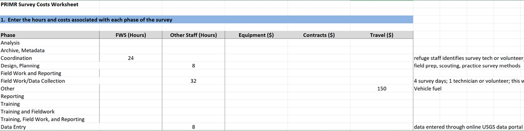

Screenshot: Example PRIMR cost spreadsheet.

4. **Limited by missing information**

For this test case, the only time this came up was missing non-labor operation cost information. Assuming unsupplied costs equate to $0 may be inaccurate.

**Example Data #4**

Showing data on current and expected surveys only

| name | annualOperationCost | avgAnnCostDollars |
| --- | --- | --- |
| Christmas Bird Count | 946 | 100.0 |
| Breeding Bird Survey | 3612 | 150.0 |
| Snowshoe Hare Population Monitoring | 3246 | 400.0 |
| Alaska Landbird Monitoring Survey (ALMS) | 7615 | 2000.0 |
| Trumpeter Swan Survey | 9846 | 6000.0 |
| Snowpack Monitoring | 4577 | 1500.0 |
| Invasive Plant Control at Point Sources on the Alaska Highway | 2308 | 0.0 |
| Moose Population Monitoring | 11385 | 8500.0 |
| Water Quantity & Quality Monitoring at Scottie Creek and Nabesna River | 9423 | 885.0 |
| Invasive Plant Occurrence along the Tetlin NWR/Alaska Highway Corridor | 6231 | 2000.0 |
| Aquatic Invertebrate Inventory | 111538 | 100000.0 |
| Water Temperature Monitoring of Streams | 3846 | 0.0 |
| Humpback Whitefish Spawning Populations: Monitoring the Effects of Harvest Level by Age Structure Analysis | 3192 | 500.0 |
| Osprey and Bald Eagle Nest Occupancy and Productivity Surveys | 3242 | 1800.0 |
| Canada Lynx Dispersal, Space and Habitat Use Patterns During a Snowshoe Hare Population Cycle | 91013 | 14330.0 |
| Early Detection Rapid Response Monitoring for Exotic Forest Pests | 4639 | NA |
| Moose Twinning Survey | 10556 | 9017.5 |
| Waterfowl Banding - dabblers | 16846 | 3000.0 |
| Scaup and Scoter breeding pair survey | 21885 | 9000.0 |
| Scaup and Scoter Brood Survey | 35913 | 8000.0 |
| Waterfowl Banding - divers/sea ducks | 67229 | 9700.0 |
| Wetland Mapping and Remote Sensing Monitoring | 11738 | 200.0 |
| Wood Bison Conservation Research | 100192 | 100000.0 |

*pink background* - indicates empty field for non-labor operation cost

5. **Inability to reliably determine individual workload from available time information**

PRIMR only captures the total survey hours by survey coordinator. This does not account for time allocated between supporting staff on those surveys. Coordinators with more support staff may be able to accommodate annual survey hours greater than their total available hours because the survey hours are being completed by other staff, while coordinators without support staff cannot. As such, total hours also does not necessarily equate to total workload for a coordinator.

Note that total costs *are* supposed to take into account relative workloads of support staff. See PRIMR Help documentation below regarding the average salary (Average FWS FTE Cost Yearly) field:

> “When survey tasks include personnel with different pay rates, the average should be weighted by the time anticipated for each person.”
6. **Difficulty efficiently and programmatically determining if a survey pertains to a pROC**

**Challenge 1:** Because taxonomy is dynamic and species names are sometimes split up into multiple species with more time and information, we end up with outdated species names that cannot be matched without knowing the synonymous scientific names. Caylen and I have uncovered 17 taxa in pROC/PRIMR data with scientific name synonyms, but there may be more. These may need to be compiled from NWRSpecies data to obtain a comprehensive set.

**Challenge 2:** Some of our pROC data contains typos. Caylen and I have found 3 scientific name typos.

**Challenge 3:** Not all surveys have species-level taxonomy information (`listedSpecies` or `nonListedSpecies` fields) supplied in PRIMR, especially those dealing with broader categories of taxa, such as landbirds or waterfowl (see Example Data #5). Instead, we only have biotic group information (see screenshot example below).

**Challenge 4:** Not all surveys with populated `listedSpecies` or `nonListedSpecies` fields have information at the species level. Some instead list “species” at the genus level.

**Challenge 5:** Surveys pertaining to abiotic resources (e.g. water quality, carbon, snow) are left out when using species information for prioritization (see Example Data #5).

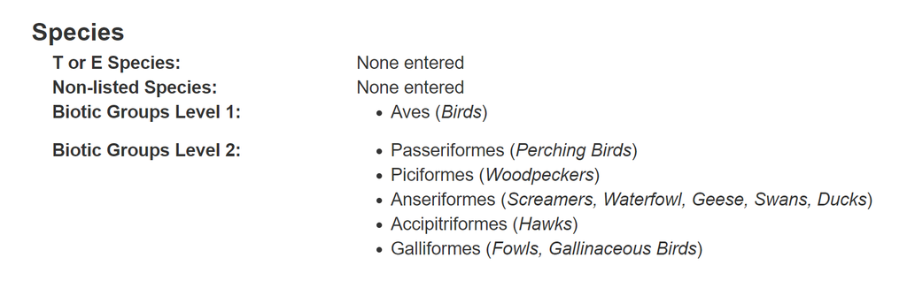

Screenshot: Example species information in PRIMR (for Christmas Bird Count Survey).

**Example Data #5**

Showing data on current and expected surveys only

| name | speciesProvided | bioticGroupProvided | priority |
| --- | --- | --- | --- |
| Christmas Bird Count | FALSE | TRUE | TRUE |
| Breeding Bird Survey | FALSE | TRUE | TRUE |
| Snowshoe Hare Population Monitoring | TRUE | FALSE | TRUE |
| Alaska Landbird Monitoring Survey (ALMS) | FALSE | TRUE | TRUE |
| Trumpeter Swan Survey | TRUE | FALSE | TRUE |
| Snowpack Monitoring | FALSE | FALSE | FALSE |
| Invasive Plant Control at Point Sources on the Alaska Highway | TRUE | FALSE | FALSE |
| Moose Population Monitoring | TRUE | FALSE | TRUE |
| Water Quantity & Quality Monitoring at Scottie Creek and Nabesna River | FALSE | FALSE | FALSE |
| Invasive Plant Occurrence along the Tetlin NWR/Alaska Highway Corridor | TRUE | FALSE | FALSE |
| Aquatic Invertebrate Inventory | FALSE | TRUE | FALSE |
| Water Temperature Monitoring of Streams | FALSE | FALSE | FALSE |
| Humpback Whitefish Spawning Populations: Monitoring the Effects of Harvest Level by Age Structure Analysis | TRUE | FALSE | TRUE |
| Osprey and Bald Eagle Nest Occupancy and Productivity Surveys | TRUE | FALSE | TRUE |
| Canada Lynx Dispersal, Space and Habitat Use Patterns During a Snowshoe Hare Population Cycle | TRUE | FALSE | TRUE |
| Early Detection Rapid Response Monitoring for Exotic Forest Pests | FALSE | TRUE | FALSE |
| Moose Twinning Survey | TRUE | FALSE | TRUE |
| Waterfowl Banding - dabblers | TRUE | FALSE | FALSE |
| Scaup and Scoter breeding pair survey | TRUE | FALSE | TRUE |
| Scaup and Scoter Brood Survey | TRUE | FALSE | TRUE |
| Waterfowl Banding - divers/sea ducks | TRUE | FALSE | TRUE |
| Wetland Mapping and Remote Sensing Monitoring | FALSE | FALSE | FALSE |
| Wood Bison Conservation Research | TRUE | FALSE | TRUE |

*bold* - indicates derived values (note: “speciesProvided” = listed or non-listed species supplied in PRIMR; “bioticGroupProvided” = level 2 biotic groups supplied in PRIMR)

*purple background* - indicates broad category surveys

*green background* - indicates abiotic surveys

## Questions To Consider

1. Is survey planning a need such that we want to capture more standardized timing information (e.g., be able to create annual Gantt charts by refuge)? If so, is this something PRIMR should do? Is it something we want badly enough that we would consider collecting that information separately? Is this even in the realm of our responsibilities?
2. We currently have no way of knowing which surveys are scheduled for a given year until a full year after the fact, assuming that reporting is completed and accurate. Is this an issue? Is there a solution?
3. Are the estimates for costs and time in PRIMR accurate and detailed enough to make the conclusions we want to make? Do we need time breakdowns by survey lifecycle step?
4. In an ideal world, should actual costs and time spent be captured in annual activity reporting?
5. Do we want to create tools (or supply metrics) for prioritization? Are we able to given current resources? If so, what would these look like? Some ideas that I have already supplied for this test case include the time/financial costs, whether the survey is cooperative, whether the survey monitors a pROC, list of refuges that are also monitoring these species, and the IMP Table 1 survey ranking. Other ideas that have come up include additional species/survey scores determined during the pROC process and available species trend information.
6. Is there information missing from PRIMR that is pertinent for survey continuation in the event of turnover?